# Supplementary R tutorial: Processing virtual fencing collar data

Two introductory workflows for time-binned and message-separated exports

Schreiber et al.

# 1 Purpose and scope

This self-contained tutorial follows the manuscript’s **Overview of Virtual Fence Data Processing Pipeline** (Fig. 3): (1) study design and data inspection; (2) spatial and temporal filtering, separate preparation of cue and position data, quality control, and temporal standardization; and (3) simple analyses. It covers the two formats illustrated in manuscript Table 1B and 1C. The code uses **synthetic data**, not actual animal observations, and runs without access to a manufacturer’s export. All example thresholds are illustrative and require justification for real studies.

The tutorial produces: a data-quality audit, cue counts and success ratios by animal/day, a position dataset for spatial analyses, and containment estimates. It does **not** fit an inferential model; the appropriate model (if any) depends on experimental design and research objectives.

# 2 1. Setup and study design

```r
packages_needed <- c("dplyr", "tidyr", "lubridate", "ggplot2", "sf", "tibble")
lapply(packages_needed, library, character.only = TRUE)
```

## 2.1 1.1 Define study boundaries and key decisions

For a real deployment, replace the example pasture with the **correct exported virtual-pasture polygon for each grazing period**. Use a local metric coordinate reference system (CRS) for distance calculations. Here, UTM zone 12N (EPSG:32612) is appropriate for our *hypothetical* Utah location. A 100-m buffer is used for **initial plausibility filtering**.

```r
# Define important timepoints, including study start/end for temporal filtering
study_start <- as.POSIXct("2026-06-01 00:00:00", tz = "UTC")
study_end   <- as.POSIXct("2026-06-04 00:00:00", tz = "UTC")

interval_min <- 15  # Let's assume our device has a default routine collar update rate of 15 min

# Example rectangular virtual pasture in projected meters.
xy <- matrix(c(450000, 4500000, 450600, 4500000,
               450600, 4500600, 450000, 4500600,
               450000, 4500000), ncol = 2, byrow = TRUE)

pasture <- sf::st_sf(pasture_id = "P1", # This is the virtual pasture active on collars during the study
                     geometry = sf::st_sfc(sf::st_polygon(list(xy)), crs = 32612))

# Create a buffer (here ~100m) around used virtual pastures to define study area
# This will be used for spatial filtering
study_area <- sf::st_buffer(pasture, dist = 100)
```

**For real files:** Import a CSV with `read.csv("collar_export.csv")`; combine exports from multiple months using `dplyr::bind_rows()`; import boundaries with `sf::st_read("pastures.gpkg")`, `sf::st_read("pastures.kml")`, or `sf::st_read("pastures.shp")`; and ancillary data (experimental treatments, animal visual IDs, etc.).

## 2.2 1.2 Simulated tracks and cue events

The following generates simple movement paths for two collars. Both export formats (time-binned and message-separated) are constructed from the same underlying simulated positions, so their differences are easier to visualize. These are just **examples**, and not manufacturer specific. Again, all of this code is used to generate simulated collar data for use later in the tutorial. None of this code is necessarily applicable to your actual data export

```r
set.seed(123)
animals <- c("cow_01", "cow_02")
time_bins <- seq(
  study_start,
  study_end - lubridate::minutes(interval_min),
  by = "15 min")
# x and y are projected coordinates (easting and northing in meters)
# Each animal moves approximately every 15 minutes.
# Horizontal errors are usually small (1-5 m).
gps_positions <- tidyr::crossing(
  animal_id = animals,
  position_timestamp = time_bins) %>%
  arrange(animal_id, position_timestamp) %>%
  group_by(animal_id) %>%
  mutate(
    x = 450300 + cumsum(rnorm(n(), 0, 16)) +
      if_else(animal_id == "cow_02", 70, 0),
    y = 4500300 + cumsum(rnorm(n(), 0, 16)),
    horizontal_error_m = runif(n(), 1, 5)) %>%
  ungroup()
# Add one deliberately erroneous GPS location.
# This will later demonstrate speed-based screening.
gps_positions <- gps_positions %>%
  mutate(
    x = if_else(
      animal_id == "cow_01" &
        position_timestamp == time_bins[40], x + 330, x))

# Simulate the underlying cue messages ONCE so both export
# formats contain the same events (audio and electrical).
# The electrical messages below represent escalations of
# preceding audio interactions, not additional audio cues.
cues_raw <- tibble::tibble(
  animal_id = c("cow_01", "cow_01", "cow_01", "cow_02",
                "cow_02", "cow_01", "cow_02", "cow_02"),
  message_timestamp = study_start + lubridate::minutes(
    c(76, 78, 79, 350, 352, 1510, 1900, 1902)),
  message_type = c("audio", "audio", "electrical", "audio",
                   "electrical", "audio", "audio", "electrical"))

# CREATE TIME-BINNED DATA
# Each cue is attributed to the interval ending at the next
# scheduled report (not the interval starting at the cue).
cue_bins <- cues_raw %>%
  mutate(timestamp = study_start + lubridate::minutes(
    ceiling(as.numeric(difftime(message_timestamp, study_start,
                                units = "mins")) / interval_min) * interval_min)) %>%
  filter(timestamp < study_end) %>%
  count(animal_id, timestamp, message_type, name = "n") %>%
  tidyr::pivot_wider(names_from = message_type, values_from = n,
                     values_fill = 0)

# Use a reporting grid that starts after the first interval.
# This ensures cues in (00:00, 00:15] belong to 00:15.
time_binned <- gps_positions %>%
  rename(timestamp = position_timestamp) %>%
  group_by(animal_id) %>%
  mutate(
    x = if_else(row_number() == 20L, lag(x), x),
    y = if_else(row_number() == 20L, lag(y), y)) %>%
  ungroup() %>%
  left_join(cue_bins, by = c("animal_id", "timestamp")) %>%
  mutate(n_audio = tidyr::replace_na(audio, 0L),
         n_electrical = tidyr::replace_na(electrical, 0L)) %>%
  select(animal_id, timestamp, x, y, horizontal_error_m,
         n_audio, n_electrical)

# CREATE MESSAGE-SEPARATED DATA
routine_messages <- gps_positions %>%
  mutate(message_timestamp = position_timestamp,
         message_type = "routine_update")

# Cue messages report the last scheduled GPS acquisition.
# This intentionally creates messages with stale positions.
cue_messages <- cues_raw %>%
  left_join(gps_positions,
    by = dplyr::join_by(animal_id,
                        message_timestamp >= position_timestamp),
    relationship = "many-to-many") %>%
  group_by(animal_id, message_timestamp, message_type) %>%
  slice_max(position_timestamp, n = 1, with_ties = FALSE) %>%
  ungroup()

message_separated <- bind_rows(routine_messages, cue_messages) %>%
  arrange(animal_id, message_timestamp) %>%
  select(animal_id, message_timestamp, position_timestamp,
         message_type, x, y, horizontal_error_m) %>%
  mutate(position_age_min = as.numeric(difftime(
    message_timestamp, position_timestamp, units = "mins")))
```

## 2.3 1.3 Compare the two data formats

Now that we have simulated a few rows of data, let’s see what that looks like in either message-separated and time-binned format. Remember that this does not apply if your data is position only. In that case, data will likely contain columns for animal_ID, latitude, longitude, and a timestamp, but no indication of cue delivery.

The first table is time-binned format. This contains one row per animal per scheduled reporting interval. Audio and electrical cues are summarized as counts occurring during the corresponding reporting interval. When we simulated data, we introduced a repeated position to demonstrate that consecutive reports do not always contain a new fix. Next, we will cover how to look for evidence of these potential occurrences in your data. In time-binned data, repeated coordinates from the same animal in time-binned data *suggest*, but do not establish, reuse of a stored GPS fix.

The second table is message-separated format. Each row represents an individual message, and separate message (when the message was generated) and position timestamps (when the fix was acquired) are given. These timestamps can differ when an existing GPS fix is reused for a subsequent message. Can you spot a re-used fix? Two or more consecutive and identical positions from the same animal with the same position timestamp but different message timestamps demonstrate a re-used fix. In this case, we can also quantify how old the reported GPS position is when each message is generated.

```r
head(time_binned, 10)
```

```
## # A tibble: 10 × 7
##    animal_id timestamp                 x        y horizontal_error_m n_audio
##    <chr>     <dttm>                <dbl>    <dbl>              <dbl>   <int>
##  1 cow_01    2026-06-01 00:00:00 450291. 4500311.               3.89       0
##  2 cow_01    2026-06-01 00:15:00 450287. 4500312.               1.76       0
##  3 cow_01    2026-06-01 00:30:00 450312. 4500288.               3.27       0
##  4 cow_01    2026-06-01 00:45:00 450313. 4500288.               3.69       0
##  5 cow_01    2026-06-01 01:00:00 450315. 4500283.               4.68       0
##  6 cow_01    2026-06-01 01:15:00 450343. 4500282.               2.30       0
##  7 cow_01    2026-06-01 01:30:00 450350. 4500263.               3.19       2
##  8 cow_01    2026-06-01 01:45:00 450330. 4500271.               1.02       0
##  9 cow_01    2026-06-01 02:00:00 450319. 4500254.               2.48       0
## 10 cow_01    2026-06-01 02:15:00 450312. 4500250.               3.55       0
## # ℹ 1 more variable: n_electrical <int>
```

```r
head(message_separated, 10)
```

```
## # A tibble: 10 × 8
##    animal_id message_timestamp   position_timestamp  message_type       x      y
##    <chr>     <dttm>              <dttm>              <chr>          <dbl>  <dbl>
##  1 cow_01    2026-06-01 00:00:00 2026-06-01 00:00:00 routine_upda… 4.50e5 4.50e6
##  2 cow_01    2026-06-01 00:15:00 2026-06-01 00:15:00 routine_upda… 4.50e5 4.50e6
##  3 cow_01    2026-06-01 00:30:00 2026-06-01 00:30:00 routine_upda… 4.50e5 4.50e6
##  4 cow_01    2026-06-01 00:45:00 2026-06-01 00:45:00 routine_upda… 4.50e5 4.50e6
##  5 cow_01    2026-06-01 01:00:00 2026-06-01 01:00:00 routine_upda… 4.50e5 4.50e6
##  6 cow_01    2026-06-01 01:15:00 2026-06-01 01:15:00 routine_upda… 4.50e5 4.50e6
##  7 cow_01    2026-06-01 01:16:00 2026-06-01 01:15:00 audio         4.50e5 4.50e6
##  8 cow_01    2026-06-01 01:18:00 2026-06-01 01:15:00 audio         4.50e5 4.50e6
##  9 cow_01    2026-06-01 01:19:00 2026-06-01 01:15:00 electrical    4.50e5 4.50e6
## 10 cow_01    2026-06-01 01:30:00 2026-06-01 01:30:00 routine_upda… 4.50e5 4.50e6
## # ℹ 2 more variables: horizontal_error_m <dbl>, position_age_min <dbl>
```

```r
message_separated %>%
  count(message_type)
```

```
## # A tibble: 3 × 2
##   message_type       n
##   <chr>          <int>
## 1 audio              5
## 2 electrical         3
## 3 routine_update   576
```

# 3 2. Initial Spatial and Temporal Filtering

After initial inspection of data structure, we can filter data to the general spatial and temporal extent of our study. To do so, we must ensure the object is a spatial points object, and that datetime is correctly parsed or codified. If you have windows of time you need to exclude, such as animal handling periods, wait to do so until after other cleaning and pre-processing steps have been completed to avoid introducing artificial gaps in the data that could be otherwise treated as missing.

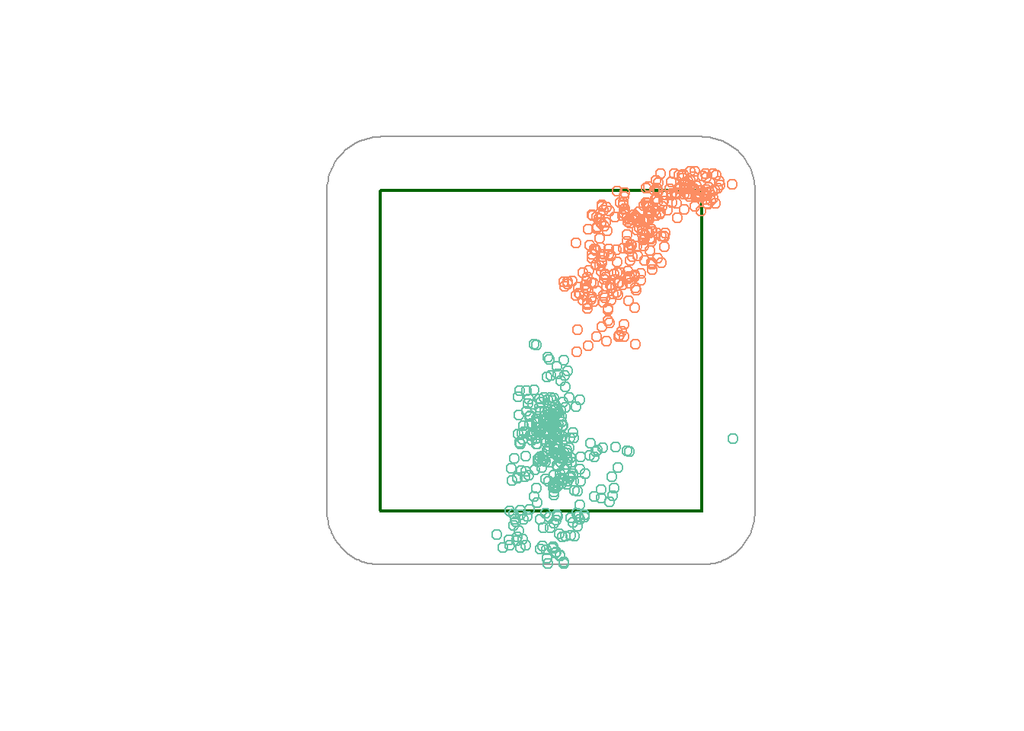

```r
# 1. Convert both datasets to spatial objects
# x = easting (m); y = northing (m)
time_binned_sf <- time_binned %>%
  st_as_sf(
    coords = c("x", "y"),
    crs = 32612,
    remove = FALSE)

message_separated_sf <- message_separated %>%
  st_as_sf(
    coords = c("x", "y"),
    crs = 32612,
    remove = FALSE)

# 2. Parse datetime columns
# These are already POSIXct, but parsing is often necessary when importing CSV files.
# Lubridate package is often useful for parsing datetime in various formats
time_binned_sf <- time_binned_sf %>%
  mutate(timestamp = as.POSIXct(timestamp, tz = "UTC"))

message_separated_sf <- message_separated_sf %>%
  mutate(
    message_timestamp = as.POSIXct(message_timestamp, tz = "UTC"),
    position_timestamp = as.POSIXct(position_timestamp, tz = "UTC"))

# 4. Filter by study timeframe and spatial extent
# st_filter() retains points intersecting the study area.
time_binned_sf <- time_binned_sf %>%
  filter(
    timestamp >= study_start,
    timestamp < study_end) %>%
  st_filter(study_area)

message_separated_sf <- message_separated_sf %>%
  filter(
    message_timestamp >= study_start,
    message_timestamp < study_end) %>%
  st_filter(study_area)

# Plot and inspect pastures and study area polygons
plot(sf::st_geometry(study_area), border = "grey60")
plot(sf::st_geometry(pasture), add = TRUE, border = "darkgreen", lwd = 2)
plot(message_separated_sf, add = TRUE)
```

# 4 3. Working with Cue Data

Cue counts are analyzed separately from GPS positions. **Do not remove cue messages merely because their attached coordinates are reused or inaccurate**: a cue can be a valid event even if its position is stale. For time-binned data, the cue columns already contain counts. For message-separated data, each audio or electrical message is a separate event. These examples assume complete cue reporting; real transmission losses may make apparently empty periods *unknown*, rather than true zeros.

```r
# TIME-BINNED: keep the counts supplied in each reporting row.
time_binned_cues <- time_binned_sf %>%
  sf::st_drop_geometry() %>%
  select(animal_id, timestamp, n_audio, n_electrical)

# MESSAGE-SEPARATED: isolate individual cue events.
message_separated_cues <- message_separated_sf %>%
  sf::st_drop_geometry() %>%
  filter(message_type %in% c("audio", "electrical")) %>%
  select(animal_id, message_timestamp, message_type)

head(message_separated_cues)
```

```
## # A tibble: 6 × 3
##   animal_id message_timestamp   message_type
##   <chr>     <dttm>              <chr>
## 1 cow_01    2026-06-01 01:16:00 audio
## 2 cow_01    2026-06-01 01:18:00 audio
## 3 cow_01    2026-06-01 01:19:00 electrical
## 4 cow_01    2026-06-02 01:10:00 audio
## 5 cow_02    2026-06-01 05:50:00 audio
## 6 cow_02    2026-06-01 05:52:00 electrical
```

## 4.1 3.1 Summarize by animal and temporal units

These analyses necessitate aggregating and summarizing cue data by units of time (hourly, daily, etc.). More details provided in the manuscript in subsection *Cue-Count-Based Analyses*. Time bins for which an animal receives no cues will contain a zero for that animal. The appropriate level of aggregation balances zero inflation risk with temporal resolution. Time-binned data will have a theoretical lower bound equal to the intended sampling interval, but message-separated data will not. However, using temporal resolution similar to the sampling interval will likely produce data where non-zero values are relatively rare. Overly course temporal resolution can reduce statistical power and preclude inference at finer temporal scales, but this will depend on the length of the study and the research questions. Some studes have used 1-hour time bins to capture finer resolution temporal trends, but daily aggregation is more common. For this tutorial, we will use **daily** bins for readability. For time-binned exports, **sum the count columns**. For message-separated exports, **count the cue messages**. The simulated electrical events are escalation events, so the number of audio interactions is the number of audio messages, not the sum of audio and electrical messages.

```r
# TIME-BINNED: sum interval counts within animal and day.
tb_cue_daily <- time_binned_cues %>%
  mutate(day = as.Date(timestamp, tz = "UTC")) %>%
# This uses calender day, but 'day of study' can be defined as number of 24-periods from study onset
# Alternatively, 'hour of study' or some other relevant time period can be used to aggregate counts
  group_by(animal_id, day) %>%
  summarise(n_audio = sum(n_audio),
            n_electrical = sum(n_electrical), .groups = "drop")

# MESSAGE-SEPARATED: count individual event messages.
ms_cue_daily <- message_separated_cues %>%
  mutate(day = as.Date(message_timestamp, tz = "UTC")) %>%
  count(animal_id, day, message_type, name = "n") %>%
  tidyr::pivot_wider(names_from = message_type, values_from = n,
                     values_fill = 0) %>%
  rename(n_audio = audio, n_electrical = electrical)

head(tb_cue_daily)
```

```
## # A tibble: 6 × 4
##   animal_id day        n_audio n_electrical
##   <chr>     <date>       <int>        <int>
## 1 cow_01    2026-06-01       2            1
## 2 cow_01    2026-06-02       1            0
## 3 cow_01    2026-06-03       0            0
## 4 cow_02    2026-06-01       1            1
## 5 cow_02    2026-06-02       1            1
## 6 cow_02    2026-06-03       0            0
```

```r
head(ms_cue_daily) # This data frame does not include zeros for animal-days with no cues
```

```
## # A tibble: 4 × 4
##   animal_id day        n_audio n_electrical
##   <chr>     <date>       <int>        <int>
## 1 cow_01    2026-06-01       2            1
## 2 cow_01    2026-06-02       1            0
## 3 cow_02    2026-06-01       1            1
## 4 cow_02    2026-06-02       1            1
```

## 4.2 3.2 Ensure zero retention

An animal with no cues on a monitored day should have a **zero**, not a missing row. We construct all combinations of known study animals and study days. This is valid only for periods when collars were active and cue reporting was sufficiently complete. In actual studies, create the grid from an animal-specific deployment/coverage schedule rather than assuming every animal was observed every day.

```r
# All animals and monitored days in this simulated study.
animal_days_grid <- tidyr::crossing(
  animal_id = animals,
  day = seq(as.Date(study_start), as.Date(study_end) - 1, by = "day"))

# TIME-BINNED: explicitly retain days with no cues.
tb_cue_daily <- animal_days_grid %>%
  left_join(tb_cue_daily, by = c("animal_id", "day")) %>%
  mutate(across(c(n_audio, n_electrical), ~ replace_na(.x, 0L)))

# MESSAGE-SEPARATED: same grid, independently applied.
ms_cue_daily <- animal_days_grid %>%
  left_join(ms_cue_daily, by = c("animal_id", "day")) %>%
  mutate(across(c(n_audio, n_electrical), ~ replace_na(.x, 0L)))

# Check to see if the data frame now includes zeros
head(ms_cue_daily)
```

```
## # A tibble: 6 × 4
##   animal_id day        n_audio n_electrical
##   <chr>     <date>       <int>        <int>
## 1 cow_01    2026-06-01       2            1
## 2 cow_01    2026-06-02       1            0
## 3 cow_01    2026-06-03       0            0
## 4 cow_02    2026-06-01       1            1
## 5 cow_02    2026-06-02       1            1
## 6 cow_02    2026-06-03       0            0
```

## 4.3 3.3 Calculating cue rates and success ratio

Animals’ responsiveness to auditory cues can be calculated as a ratio. Virtual fence user interfaces often report a simple auditory-electrical cue ratio, but electrical cues are a conditional subset of auditory cues, and this ratio has a lower bound of 0.5. Thus, responsiveness is better modeled as “success ratio” (i.e., audio only ratio) which describes the ratio of “successes” (auditory cues that do not escalate into an electrical cue) to total interactions with the virtual fence (total auditory cues). Because we chose daily aggregation, cue counts are in terms of **cues per animal per day**. Success ratio assumes each electrical cue represents an escalation of one auditory cue and that the export records both event types completely. A day (or whatever temporal unit of aggregation is used) with zero audio interactions has an **undefined** success ratio, not 100% success. Check each manufacturer’s cue sequence and definitions before applying this formula.

```r
# TIME-BINNED: daily cue counts and success ratio.
tb_cue_results <- tb_cue_daily %>%
  mutate(success_ratio = if_else(n_audio > 0,
    (n_audio - n_electrical) / n_audio, NA_real_))

# MESSAGE-SEPARATED: the same metrics from event counts.
ms_cue_results <- ms_cue_daily %>%
  mutate(success_ratio = if_else(n_audio > 0,
    (n_audio - n_electrical) / n_audio, NA_real_))

print(tb_cue_results)
```

```
## # A tibble: 6 × 5
##   animal_id day        n_audio n_electrical success_ratio
##   <chr>     <date>       <int>        <int>         <dbl>
## 1 cow_01    2026-06-01       2            1           0.5
## 2 cow_01    2026-06-02       1            0           1
## 3 cow_01    2026-06-03       0            0          NA
## 4 cow_02    2026-06-01       1            1           0
## 5 cow_02    2026-06-02       1            1           0
## 6 cow_02    2026-06-03       0            0          NA
```

```r
print(ms_cue_results)
```

```
## # A tibble: 6 × 5
##   animal_id day        n_audio n_electrical success_ratio
##   <chr>     <date>       <int>        <int>         <dbl>
## 1 cow_01    2026-06-01       2            1           0.5
## 2 cow_01    2026-06-02       1            0           1
## 3 cow_01    2026-06-03       0            0          NA
## 4 cow_02    2026-06-01       1            1           0
## 5 cow_02    2026-06-02       1            1           0
## 6 cow_02    2026-06-03       0            0          NA
```

# 5 4. Creating a Position Dataset

The position workflow differs from the cue workflow. Let’s create a position dataset under a new name to reflect this divergence.

```r
# TIME-BINNED: rename to a position dataset to avoid overwriting original data
tb_positions <- time_binned_sf

# MESSAGE-SEPARATED: rename to a position dataset to avoid overwriting original data
ms_positions <- message_separated_sf
```

## 5.1 4.1 Inspect temporal uniformity and search for position re-use

Some devices will re-use a stored position in multiple consecutive messages (i.e., rows of data) without collecting a new fix. If data contains separate message and position timestamps (such as our message-separated dataset example), this is simple to discern by looking for messages (i.e., rows of data) with the same animal_ID, coordinates, and position timestamp. If datasets do not reveal separate position and message timestamps, look for consecutive messages (i.e., rows of data) with the same animal_ID and identical coordinates. These suggest but do not definitively prove position re-use. For illustration, we flag and remove consecutive exact coordinate repeats; this can also discard genuine stationary observations. The likelihood of this depends on both position specifcity (number of decimals the original lat/lon reported) and the magnitude of typical GPS fix error. Re-used positions should be removed from the dataset. Both before and after removing duplicates, use histograms to visually inspect the fixrate of the data (such as in Fig. 2 and Fig. 3 of the manuscript). See manuscript for more details on interpreting these histograms. Large gaps may indicate lost transmissions or reduced sampling, while very short intervals may reflect event-triggered reporting.

### 5.1.1 4.1.1 Inspect message and position timestamp intervals

For our time-binned data example, we can only calculate intervals between reported timestamps, because a distinct ‘fix time’ is not given. For message-separated data, we can separately examine intervals between messages and between the actual GPS position timestamps.

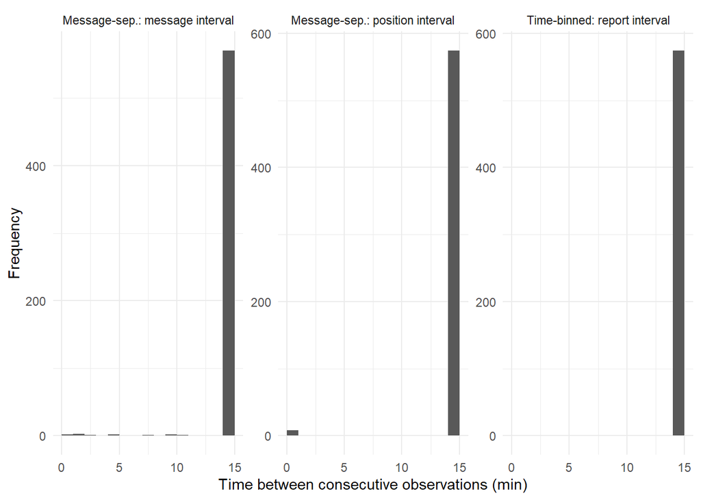

```r
# TIME-BINNED: intervals between reported positions
tb_intervals <- tb_positions %>%
  sf::st_drop_geometry() %>%
  arrange(animal_id, timestamp) %>%
  group_by(animal_id) %>%
  mutate(
    dt_min = as.numeric(difftime(
      timestamp, lag(timestamp), units = "mins"))) %>%
  ungroup() %>%
  mutate(interval_type = "Time-binned: report interval")

# MESSAGE-SEPARATED: intervals between messages
ms_message_intervals <- ms_positions %>%
  sf::st_drop_geometry() %>%
  arrange(animal_id, message_timestamp) %>%
  group_by(animal_id) %>%
  mutate(
    dt_min = as.numeric(difftime(
      message_timestamp, lag(message_timestamp),
      units = "mins"))) %>%
  ungroup() %>%
  mutate(interval_type = "Message-sep.: message interval")

# MESSAGE-SEPARATED: intervals between GPS timestamps
ms_position_intervals <- ms_positions %>%
  sf::st_drop_geometry() %>%
  arrange(animal_id, position_timestamp, message_timestamp) %>%
  group_by(animal_id) %>%
  mutate(
    dt_min = as.numeric(difftime(
      position_timestamp, lag(position_timestamp), units = "mins"))) %>%
  ungroup() %>%
  mutate(interval_type = "Message-sep.: position interval")


# Compare all three distributions
bind_rows(
  tb_intervals,
  ms_message_intervals,
  ms_position_intervals) %>%
  filter(!is.na(dt_min)) %>%
  ggplot(aes(x = dt_min)) +
  geom_histogram(binwidth = 1, boundary = 0) +
  facet_wrap(~ interval_type, scales = "free_y") +
  labs(
    x = "Time between consecutive observations (min)",
    y = "Frequency") +
  theme_minimal()
```

### 4.1.2 Identify duplicate positions

Notice that the message-separated position histogram may contain numerous zero-minute intervals. These arise when multiple messages reference the same GPS acquisition timestamp, even though their message timestamps differ. We now quantitatively summarize observations that have identical coordinates to the immediately preceding observation from the same animal. For message-separated data, we additionally require identical GPS acquisition timestamps. This provides stronger evidence that the same position was reported more than once. Rather than simply counting duplicated rows, we will summarize the length of consecutive sequences of identical positions, including the original observation. For example, a sequence length of 3 means one original observation followed by two repeats.

In message-separated data, this is also a good time to create multiple fixrate histograms based on each message type. Doing so will confirm if 100% of repeat positions are produced by a certain message type (e.g., cue messages). If so, these message types can simply be removed. We can also use this technique to test whether removing cue messages and leaving only routine collar position updates results in temporally uniform data (this will be important to know later on, depending on your analytical goals).

```r
# TIME-BINNED: identify consecutive repeated coordinates
tb_positions <- tb_positions %>%
  arrange(animal_id, timestamp) %>%
  group_by(animal_id) %>%
  mutate(
    repeated_position = x == lag(x) & y == lag(y),
    repeated_position = replace_na(repeated_position, FALSE),
    sequence_id = cumsum(!repeated_position)) %>%
  ungroup()

# MESSAGE-SEPARATED: identify repeated coordinates AND timestamps
ms_positions <- ms_positions %>%
  arrange(animal_id, message_timestamp) %>%
  group_by(animal_id) %>%
  mutate(
    repeated_position =
      x == lag(x) &
      y == lag(y) &
      position_timestamp == lag(position_timestamp),
    repeated_position = replace_na(repeated_position, FALSE),
    sequence_id = cumsum(!repeated_position)) %>%
  ungroup()

# TIME-BINNED: count consecutive repeat sequence lengths
tb_repeat_table <- tb_positions %>%
  sf::st_drop_geometry() %>%
  group_by(animal_id, sequence_id) %>%
  summarise(sequence_length = n(), .groups = "drop") %>%
  count(sequence_length, name = "n_sequences") %>%
  arrange(sequence_length)

print(tb_repeat_table)
```

```
## # A tibble: 2 × 2
##   sequence_length n_sequences
##             <int>       <int>
## 1               1         572
## 2               2           2
```

```r
# MESSAGE-SEPARATED: count consecutive repeat sequence lengths
ms_repeat_table <- ms_positions %>%
  sf::st_drop_geometry() %>%
  group_by(animal_id, sequence_id) %>%
  summarise(sequence_length = n(), .groups = "drop") %>%
  count(sequence_length, name = "n_sequences") %>%
  arrange(sequence_length)

print(ms_repeat_table)
```

```
## # A tibble: 4 × 2
##   sequence_length n_sequences
##             <int>       <int>
## 1               1         572
## 2               2           1
## 3               3           2
## 4               4           1
```

### 5.1.2 4.1.3 Remove duplicate positions

In message-separated data, if all repeat positions are produced by a certain message type (e.g., cue messages), those message types can simply be removed. Otherwise, we can retain the first observation in each sequence and remove subsequent repeats (regardless of message type); that is what we do in the current example. After removing duplicates, we can see that more positions are ultimately retained in the message-separated dataset, because when cue-associated positions occur within their own rows, and contain unique fixes, they effectively increase the temporal resolution of the data.

```r
# TIME-BINNED: remove consecutive identical coordinates
tb_positions <- tb_positions %>%
  filter(!repeated_position) %>%
  select(-repeated_position, -sequence_id)

# MESSAGE-SEPARATED: remove repeated GPS fixes
ms_positions <- ms_positions %>%
  filter(!repeated_position) %>%
  select(-repeated_position, -sequence_id)

# Report the number of retained positions
tibble(
  format = c("Time-binned", "Message-separated"),
  n_retained_positions = c(nrow(tb_positions), nrow(ms_positions)))
```

```
## # A tibble: 2 × 2
##   format            n_retained_positions
##   <chr>                            <int>
## 1 Time-binned                        574
## 2 Message-separated                  576
```

### 5.1.3 4.1.4 Reinspect GPS fix intervals after removing repeats

Finally, we recalculate intervals between the retained observations. This allows us to assess whether the distribution of GPS sampling intervals becomes more consistent after removing reused positions. At this stage, use only position timestamp fixrates, to visualize the uniformity of the underlying fix collection process. Whether or not irregular data is a problem that needs to be addressed will depend on downstream analyses.

The resulting message-separated histogram demonstrates that after removing duplicate positions and using position timestamps rather than message timestamps, the remaining data is uniform in time. This will not always be the case. See Fig. 2 in the manuscript for a real-data example.

The resulting time-binned histogram demonstrates that, after removing duplicate positions, the remaining data is mostly uniform in time. A few exceptions exist where true fixrate is 30 min rather than 15 min. This reveals that a few 15-min bins are now “skipped” because they likely re-used old positions. This general pattern will not always be the case. See Fig. 3 in the manuscript for a real-data example. If fixrates appear to exactly align with uniform time bins (such as the simulated example in this tutorial), it is possible that the collar artificially assigns its positions to regularly sent messages, despite being collected irregularly.

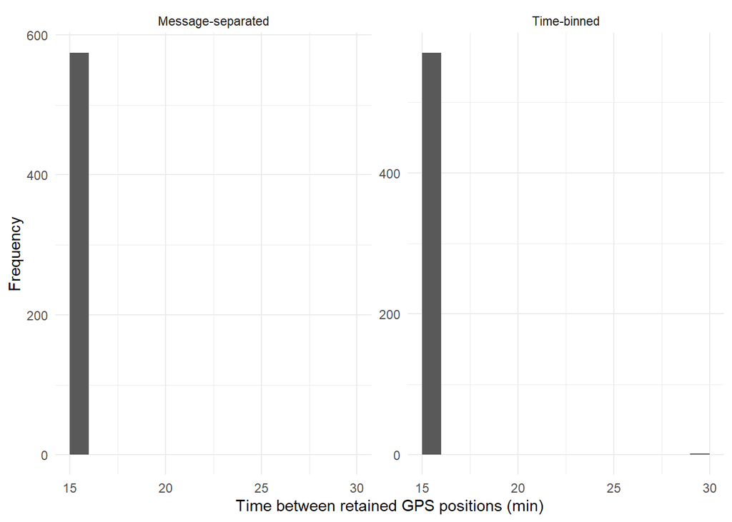

```r
# TIME-BINNED: intervals between retained positions
tb_intervals_clean <- tb_positions %>%
  sf::st_drop_geometry() %>%
  arrange(animal_id, timestamp) %>%
  group_by(animal_id) %>%
  mutate(
    dt_min = as.numeric(difftime(
      timestamp, lag(timestamp), units = "mins"))) %>%
  ungroup() %>%
  mutate(format = "Time-binned")


# MESSAGE-SEPARATED: intervals between retained GPS fixes
ms_intervals_clean <- ms_positions %>%
  sf::st_drop_geometry() %>%
  arrange(animal_id, position_timestamp) %>%
  group_by(animal_id) %>%
  mutate(
    dt_min = as.numeric(difftime(
      position_timestamp, lag(position_timestamp), units = "mins"))) %>%
  ungroup() %>%
  mutate(format = "Message-separated")


# Plot cleaned interval distributions
bind_rows(
  tb_intervals_clean,
  ms_intervals_clean) %>%
  filter(!is.na(dt_min)) %>%
  ggplot(aes(x = dt_min)) +
  geom_histogram(binwidth = 1, boundary = 0) +
  facet_wrap(~ format, scales = "free_y") +
  labs(
    x = "Time between retained GPS positions (min)",
    y = "Frequency") +
  theme_minimal()
```

## 5.2 4.2 Inspect and remove unrealistic steps/locations

Calculate speed between consecutive fixes in a **projected CRS**. A large speed can indicate a faulty point, but it can also reflect a genuine movement or a long gap. To illustrate an isolated GPS spike, we flag a location only when **both** its incoming and outgoing step speeds exceed the chosen threshold. In this example, we use 0.2 m/s as a speed threshold to capture a simulated erroneous point. Because our simulated pasture is small, we have to use a speed threshold much lower than would normally be appropriate. Generally a threshold of 3-5 m/s is more approprite. This is a simplified screening rule, not a general-purpose telemetry error filter. Inspect flagged points and tracks before removal. This step would be the same for both dataset types, but we include code for both, despite redundancy.

```r
# We use a low m/s threshold to comply with our simulated points
# Generally, a higher threshold (~3-5 m/s) is recommended, but should be biologically informed
limit_m_s <- 0.2

# TIME-BINNED: flag unlikely positions (i.e., "spikes").
tb_positions <- tb_positions %>%
  arrange(animal_id, timestamp) %>%
  group_by(animal_id) %>%
  mutate(
    step_in_m = sqrt((x - lag(x))^2 + (y - lag(y))^2),
    step_out_m = sqrt((lead(x) - x)^2 + (lead(y) - y)^2),
    dt_in_s = as.numeric(difftime(timestamp, lag(timestamp), units = "secs")),
    dt_out_s = as.numeric(difftime(lead(timestamp), timestamp, units = "secs")),
    speed_in = if_else(dt_in_s > 0, step_in_m / dt_in_s, NA_real_),
    speed_out = if_else(dt_out_s > 0, step_out_m / dt_out_s, NA_real_),
    likely_spike = coalesce(speed_in > limit_m_s &
                             speed_out > limit_m_s, FALSE)) %>%
  ungroup()

# MESSAGE-SEPARATED: flag unlikely positions using GPS acquisition timestamps.
ms_positions <- ms_positions %>%
  arrange(animal_id, position_timestamp) %>%
  group_by(animal_id) %>%
  mutate(
    step_in_m = sqrt((x - lag(x))^2 + (y - lag(y))^2),
    step_out_m = sqrt((lead(x) - x)^2 + (lead(y) - y)^2),
    dt_in_s = as.numeric(difftime(position_timestamp, lag(position_timestamp), units = "secs")),
    dt_out_s = as.numeric(difftime(lead(position_timestamp), position_timestamp, units = "secs")),
    speed_in = if_else(dt_in_s > 0, step_in_m / dt_in_s, NA_real_),
    speed_out = if_else(dt_out_s > 0, step_out_m / dt_out_s, NA_real_),
    likely_spike = coalesce(speed_in > limit_m_s &
                             speed_out > limit_m_s, FALSE)) %>%
  ungroup()

# Summarize the number and percentage of flagged positions.
bind_rows(
  tb_positions %>%
    st_drop_geometry() %>%
    mutate(format = "Time-binned"),
  ms_positions %>%
    st_drop_geometry() %>%
    mutate(format = "Message-separated")) %>%
  group_by(format) %>%
  summarise(
    n_positions = n(),
    n_flagged = sum(likely_spike),
    percent_flagged = 100 * n_flagged / n_positions,
    .groups = "drop")
```

```
## # A tibble: 2 × 4
##   format            n_positions n_flagged percent_flagged
##   <chr>                   <int>     <int>           <dbl>
## 1 Message-separated         576         1           0.174
## 2 Time-binned               574         1           0.174
```

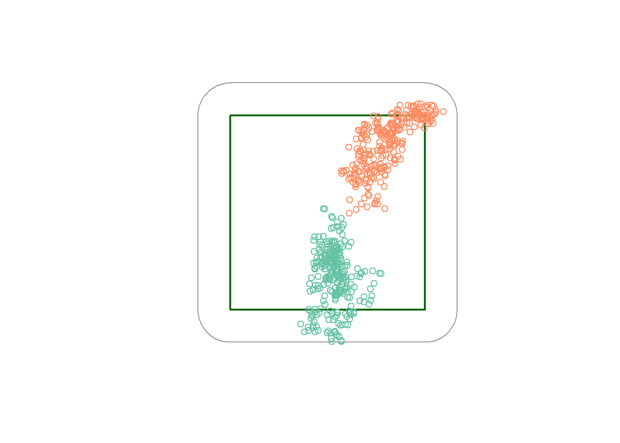

```r
# TIME-BINNED: remove flagged positions.
tb_positions <- tb_positions %>%
  filter(!likely_spike)

# MESSAGE-SEPARATED: remove flagged positions.
ms_positions <- ms_positions %>%
  filter(!likely_spike)

# Inspect cleaned positions against the virtual pasture
# (message-separated example only).
plot(sf::st_geometry(study_area), border = "grey60")
plot(sf::st_geometry(pasture), add = TRUE,
     border = "darkgreen", lwd = 2)
plot(ms_positions, add = TRUE)
```

```r
# Notice the point that has been removed?
```

# 6 5. Position-Based Analyses

The next steps will depend on your analytical goals. If you intend to conduct analyses compatible with or related to modeled utilization-distributions (UD’s), then you can proceed to construct a UD. Popular methods include a dynamic brownian bridge (dBBMM), which is available through the `move` package. Alternatively, continuous time movement models are available in the ctmm package. In the manuscript we demonstrate both a UD from both `move::brownian.bridge.dyn()` and `ctmm::occurence()` (Fig. 1 and Fig. 5). We will not further demonstrate the use of these methods within this tutorial. Both a dBBMM and a CTMM can accommodate data that is relatively irregular in time, and can incorporate GPS error values, meaning further pre-processing may not be necessary. However, significant temporal irregularity and extreme error estimates can sometimes still present issues when creating these movement models. Online resources for these packages are abundant.

For conventional point- and step-based movement/distribution analyses, it is recommended to filter out points with high error potential. Some point- and step-based analyses can accommodate slight to moderate temporal irregularity. However, it is still recommended to mitigate irregularity, because it often represented biased underlying sampling process in VF collars, such as more frequent fixrate near virtual boundaries, or less frequent fixrate in parts of the pasture with poor connectivity.

## 6.1 5.1 Filter positions with high error potential

Apply appropriate accuracy thresholds, which should be done after examining their distributions. Here we use horizontal accuracy as an example uncertainty metric in meters, not the same as HDOP. These simulated values are mostly 1–5 m, so the illustrative 10-m threshold removes few or no points. In actual deployments, quality filtering can be spatially biased if accuracy changes near VF boundaries. See manuscript (Fig. 5) for more information.

```r
accuracy_limit_m <- 10 # Example GPS horizontal-error threshold (not a universal recommendation)

summary(tb_positions$horizontal_error_m)
```

```
##    Min. 1st Qu.  Median    Mean 3rd Qu.    Max.
##   1.014   1.990   2.994   2.998   3.974   4.999
```

```r
# TIME-BINNED: inspect reported horizontal error.
tb_positions_clean <- tb_positions %>%
  filter(horizontal_error_m <= accuracy_limit_m)

# MESSAGE-SEPARATED: apply the same illustrative rule.
ms_positions_clean <- ms_positions %>%
  filter(horizontal_error_m <= accuracy_limit_m)

# For real data, also compare the locations and proportion
# of rejected fixes against VF boundaries and landscape.
```

## 6.2 5.2 Ensure data are temporally uniform?

Recheck fix intervals **after cleaning**. If fix intervals appear irregular, compare fix intervals of dataset before and after quality filtering, but after removal of likely duplicates. It is important to do so with pre- and post-filtered datasets, because irregularity can result from either aggressive cleaning/filtering, or from an irregular fix generating process. Ultimately, an attempt to mitigate temporal irregularity should be guided by both intended analyses, temporal resolution of those analyses, and the severity of irregularity. Genuinely reported GPS fix timestamps, especially those with second-level resolution, can be expected to have some degree of irregularity. Rare and minor irregularity is typically not problematic. Moderate to large datasets in which GPS fixes have perfect, second-level uniformity, are suspicious, and may indicate that position timestamps were artificially standardized after collection.

Irregular fix generating processes could result from a few underlying differences, and resemble one of three fixrate distributions, each with distinct analytical implications. In the first scenario, the fixrate distribution will likelypeak at the programmed/default fixrate, and have a left tail but no right tail, indicating fixes sometimes occur more frequently than expected but never (or very rarely) less frequently. As we alluded to in section *4.1.4*, this likely occurs because more frequent fixes result from VF interactions (i.e., cue-associated positions). If so, removing cue messages while leaving routine position updates, can regularize data (only applicable for message-separated datasets). If isolating and removing cue-associated positions is not possible, such as with time-binned data, or doing so does not fix the irregularity, another condition such as animal activity level may influence fixrate. In this case, re-sampling along a uniform time interval (similar to the default fixrate) is the recommended approach.

In the second scenario, the fixrate distribution will peak at the programmed/default fixrate, and have a right tail but no left tail, indicating fixes sometimes occur less frequently than expected but never (or very rarely) more frequently. As we show in Fig. 1 of the manuscript, this could occur due to connectivity or data transmission issues. It could also occur if devices reduce fixrates for inactive animals or animals not near the VF. In this case, removing data, either through omitting cue messages or re-sampling, will not improve gaps in the data.

In the third scenario, the fixrate distribution will likely peak at the programmed/default fixrate, and have both right and left tails, indicating fixes sometimes occur less frequently and sometimes more frequently than expected. This is demonstrated in Fig. 3 of the manuscript. This distribution likely results from a combination of the factors described in the preceding scenarios. As per the first scenario, removal of cue-associated positions (for message-separated data) or re-sampling are recommended to reduce the left tail. However, these approaches will not reduce the right tail.

If these approaches for mitigating irregularity are not effective, and significant irregularity persists to a degree incompatible with the intended analysis, it may be possible to construct a modeled UD using dBBMM or CTMM, and use the UD directly, or sample points from the UD for use in another analysis. In this case, beware that these are modeled not observed points. Regardless, in this tutorial, we demonstrate how to re-sample positions along a uniform time interval (with the message-separated dataset only, as is more common). However, this approach may not always be appropriate or helpful. See manuscript for more details on mitigating irregularity.

```r
interval_min <- 15  # Example re-sampling interval (see manuscript for details on selecting re-sampling interval)

# This function selects one observed fix closest to each interval bounds
# Interval bounds are based on study_start and the nominal interval.
ms_positions_15m <- ms_positions_clean %>%
    mutate(
      elapsed_min = as.numeric(difftime(position_timestamp, study_start, units = "mins")),
      bin_index = floor(elapsed_min / interval_min),
      offset_min = elapsed_min - bin_index * interval_min) %>% # This is to select the fix closest to interval bound
    group_by(animal_id, bin_index) %>%
    slice_min(offset_min, n = 1, with_ties = FALSE) %>%
    ungroup()

# Count bins with retained fixes; a missing bin remains missing.
tibble::tibble(n_fixes = nrow(ms_positions_15m))
```

```
## # A tibble: 1 × 1
##   n_fixes
##     <int>
## 1     575
```

## 6.3 5.3 Virtual fence analyses

For spatial analyses, reference each fix against the **virtual pasture active at that time**. Our example has one pasture throughout the study. Some VF systems do not allow for exporting of virtual pasture polygons, in which case manual geo-referencing may be necessary. Other manufactures include a .csv of all used virtual pastures along with primary data export. These will need to be converted to spatial polygons. After this, join positions to a timestamped pasture history before spatial calculations.

### 6.3.1 5.3.1 Virtual fence effectiveness (containment)

Containment is the proportion of **observed, retained fixes** inside the designated pasture, not necessarily the exact fraction of elapsed time inside, but with proper data cleaning, filtering, and pre-processing, it should be similar. Here we include boundary points as inside using `st_intersects()`. We aggregate by animal and day and preserve days with zero *outside* points. **Do not define a day with no GPS observations as having zero containment**; its containment is unknown. We use the re-sampled message-separated dataset only, but these steps will be the same for both.

```r
# Calculate whether points are in or out
ms_containment_points <- ms_positions_15m %>%
  mutate(inside = lengths(sf::st_intersects(geometry, pasture)) > 0,
         day = as.Date(position_timestamp, tz = "UTC"))

# Aggregate daily
ms_containment_daily <- ms_containment_points %>%
  sf::st_drop_geometry() %>%
  group_by(animal_id, day) %>%
  summarise(n_inside = sum(inside), n_outside = sum(!inside),
            n_fixes = n(), containment = mean(inside), .groups = "drop")

# Inspect results
print(ms_containment_daily)
```

```
## # A tibble: 6 × 6
##   animal_id day        n_inside n_outside n_fixes containment
##   <chr>     <date>        <int>     <int>   <int>       <dbl>
## 1 cow_01    2026-06-01       95         0      95       1
## 2 cow_01    2026-06-02       43        53      96       0.448
## 3 cow_01    2026-06-03       96         0      96       1
## 4 cow_02    2026-06-01       96         0      96       1
## 5 cow_02    2026-06-02       96         0      96       1
## 6 cow_02    2026-06-03       41        55      96       0.427
```

### 6.3.2 5.3.2 Proximity to the virtual fence

Calculate distance from each observed fix to the pasture boundary. Here, we classify a point as boundary-proximal when it is **inside** the pasture and no more than 5 m from the boundary. The 5-m threshold is illustrative and should be evaluated relative to GPS uncertainty, collar cue-zone definitions, and study goals. This reflects proportion of **observed, retained fixes** near the VF, not necessarily the exact fraction of elapsed time proximal to the VF, but with proper data cleaning, filtering, and pre-processing, it should be similar. We aggregate by animal and day. We use the re-sampled message-separated dataset only, but these steps will be the same for both. A similar and potentially more robust analysis can be conducted while accounting for other covariates by performing an RSF, and defining the VF-proximal zone as a binary covariate.

```r
# Convert the polygon boundary to a line geometry.
vf_boundary <- sf::st_boundary(sf::st_geometry(pasture))

# Perform spatial calculation.
ms_boundary_points <- ms_containment_points %>% # we use containment points as some steps are shared with that analysis
  mutate(distance_to_vf_m = as.numeric(sf::st_distance(geometry, vf_boundary)[, 1]),
         near_vf = inside & distance_to_vf_m <= 5)

# Calculate fraction of retained fixes near the boundary.
ms_boundary_daily <- ms_boundary_points %>%
  sf::st_drop_geometry() %>%
  group_by(animal_id, day) %>%
  summarise(n_near = sum(near_vf), n_fixes = n(),
            proportion_near = mean(near_vf), .groups = "drop")

print(ms_boundary_daily)
```

```
## # A tibble: 6 × 5
##   animal_id day        n_near n_fixes proportion_near
##   <chr>     <date>      <int>   <int>           <dbl>
## 1 cow_01    2026-06-01      0      95          0
## 2 cow_01    2026-06-02      2      96          0.0208
## 3 cow_01    2026-06-03      0      96          0
## 4 cow_02    2026-06-01      1      96          0.0104
## 5 cow_02    2026-06-02      0      96          0
## 6 cow_02    2026-06-03      9      96          0.0938
```

## 6.4 5.4 Exploring other analyses

The manuscript also describes other responses that can be derived from collar data. These require further processing, additional assumptions, or covariates, and are **not implemented** in this introductory tutorial:

- **Movement:** step length, travel distance per unit time, velocity, turning angle, and path tortuosity. Gaps and irregular fix intervals require particular attention.
- **Distribution:** point-density maps, distribution evenness, utilization distributions (UDs), and behavior-specific space use when validated activity classifications are available.
- **Habitat selection:** resource selection functions (RSFs), step selection functions (SSFs), and integrated SSFs (iSSFs), including appropriately defined available habitat or alternative steps.
- **Virtual fence learning:** time to enter a newly accessible area after a boundary shift, and changes in cue frequency or success ratio over time.
- **Social association:** herd-level mean pairwise distance, requiring synchronized fixes across animals and adequate concurrent collar coverage.

All of these analyses depend on whether observations represent **new acquisitions**, reused stored locations, or model-estimated positions. GPS occurrence alone does not establish grazing behavior.